# homework dv 1-3

## Question 4

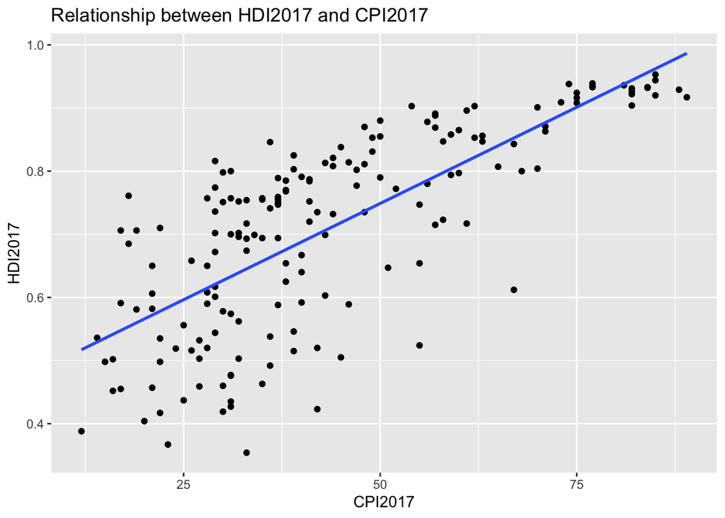

```r
ggplot(cdf,
       aes(x = CPI2017,
           y = HDI2017)) +
  geom_point() +
  labs(title = "Relationship between HDI2017 and CPI2017") +
  geom_smooth(method = "lm", se = FALSE)
```

I added the geom_smooth() function to the scatterplot code to include the blue line on the graph that helps illustrate the relationship between CPI2017 and HDI2017. The above scatterplot displays the lm or “linear model” method, while the below scatterplot displays the gam or “generalized additive model” method. The differences are that the lm method has a straight blue “best fit” line, whlie the gam method has a curved/bent line that is slightly concave down. I prefer the linear model (lm) method because the straight line is more aesthetic and easier to observe how each data point aligns with overall pattern, like when observing residuals.

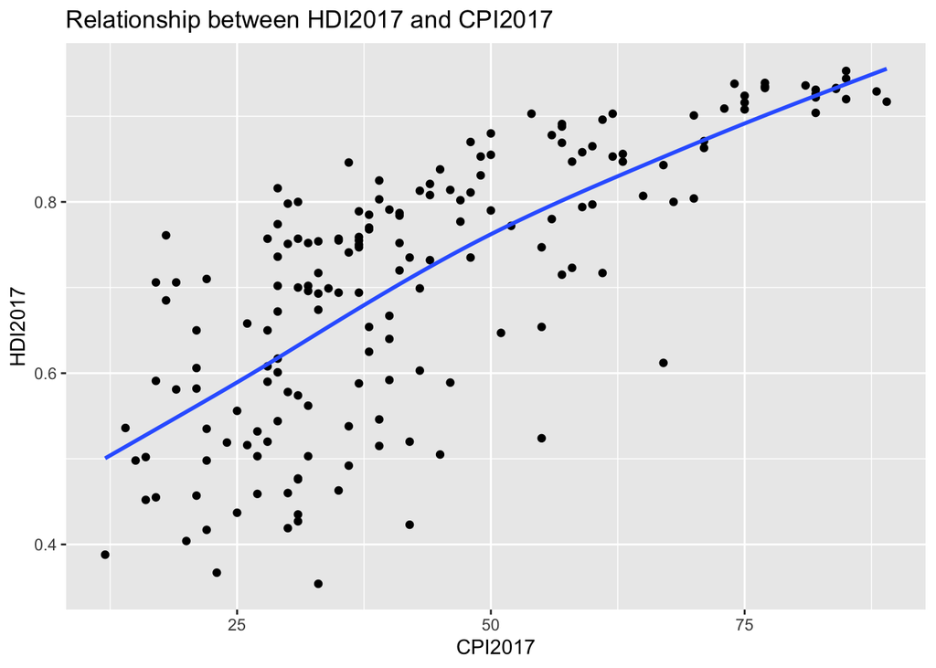

```r
ggplot(cdf,
       aes(x = CPI2017,
           y = HDI2017)) +
  geom_point() +
  labs(title = "Relationship between HDI2017 and CPI2017") +
  geom_smooth(method = "gam", se = FALSE)
```